# Homework 1 - Bayesian Statistics 2025

Claudio Agostinelli, Department of Mathematics, University of Trento, Italy

16 April 2025

# Exercise 1

A Linear Congruential Generator (LCG) is given by
$$\begin{align*}
x_i & = a_0 + a_1 x_{i-1} \mod M \\
u_i & = x_i / M
\end{align*}$$

and when $a_0=0$ yields the Multiplicative Congruential Generator (MCG). [Marsaglia (1968)](https://www.jstor.org/stable/58853?seq=1) showed that the consecutive tuples $(u_i, \ldots, u_{i+k-1})$ from an MCG have a lattice structure. The figure below shows some examples for $k=2$, using $M$ small enough for us to see the structure

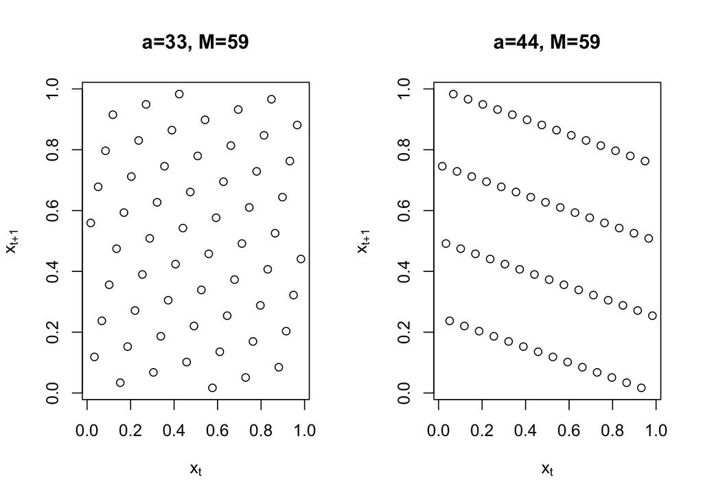

A lattice is an infinite set of the form

$$\mathcal{L} = \left\{ \sum_{j=1}^k \alpha_j v_j | \alpha_j \in
\mathbb{Z} \right\} \ ,$$

where $v_j$ are linearly independent basis vectors in $\mathbb{R}^k$. The tuples from the MCG are the intersection of the infinite set $\mathcal{L}$ with the unit cube $[0,1)^k$.

The lattice points in $k$ dimensions lie within sets of parallel $k-1$ dimensional planes. Lattices where those planes are far apart miss much of the space, and so are poor approximations to the desired uniform distribution. For an MCG with period $P$, [Marsaglia (1968)](https://www.jstor.org/stable/58853?seq=1) shows that there is always a system of $(k!P )^{1/k}$ or fewer parallel planes that contain all of the $k$-tuples.

- For each of the two MCG described above:
  - Redo the figures above.
  - Find one basis $v$ and report it in the figure.
  - Find the distance among the parallel lines.
- The lattice on the right of the figure above is not the worst one for $M=59$.
  - Find another value of $a$ for which the period of $x_i = a x_{i-1} \mod 59$, starting with $x_1=1$ equals $59$, but the 59 points $u_i, u_{i+1}$ for $u_i = x_i/59$ lie on parallel lines more widely separated than those with $a=44$.
  - Plot the points and compute the separation between those lines;
  - Hint: identify a lattice point on one of the lines, and drop a perpendicular from it to a line defined by two points on another of the lines.

# Exercise 2

Suppose that we are using an MCG with period $P \le 2^{32}$.

- Evaluate Marsaglia’s upper bound on the number of planes which will contain all consecutive $k = 10$ tuples from the MCG.
- Repeat the previous part, but assume now a much larger bound $P \le 2^{64}$.
- Repeat the previous two parts for $k = 20$ and again for $k = 100$.
- Hint: Read carefully the previous exercise!

# Exercise 3

Suppose that an MCG becomes available with period $2^{19937} - 1$. What is Marsaglia’s upper bound on the number of planes in $[0, 1)^{10}$ that will contain all $10$-tuples from such a generator?

# Exercise 4

A relatively new and quite different generator type is the Inversive Congruential Generator, ICG. For a prime number $M$ the ICG update is

$$x_i =
\begin{cases}
a_0 + a_1 x_{i-1}^{-1} \mod M & \qquad x_{i-1} \neq 0 \ , \\
a_0 & \qquad x_{i-1} = 0 \ .
\end{cases}$$

When $x \neq 0$, then $x^{-1}$ is the unique number in $\{0, 1, \ldots, M -1 \}$ with $x x^{-1} = 1 \mod M$. The ICG behaves as if it uses the convention $0^{-1} = 0$. These methods produce a sequence of integer values $x_i \in \{0, 1, \ldots, M - 1 \}$, that is, integers modulo $M$. With good choices for the constants $a_j$ and $M$, the $x_i$ can simulate independent random integers modulo $M$. See also the wikipedia page en.wikipedia.org/wiki/Inversive_congruential_generator.

Consider the ICG for $M=59$, $a_0=1$ and $a_1 = 17$.

- What is the period of this generator?
- Plot the consecutive pairs $(u_i, u_{i+1})$ where $u_i = x_i/59$.